#### Name : Layanika Vinay Saravanan

#### Student ID : 8934459

#### Topic : Lab 2

# Part 1:

### 1. Get the data.

```python
import pandas as pd
from sklearn import datasets# Load the diabetes dataset
diabetes_data = datasets.load_diabetes()
```

```python
# Explore the keys of the dataset
print(diabetes_data.keys())
```

```
dict_keys(['data', 'target', 'frame', 'DESCR', 'feature_names', 'data_filename', 'target_filename', 'data_module'])
```

```python
# Features (predictor variables)
X = diabetes_data.data

# Target (diabetes progression)
y = diabetes_data.target
```

```python
print(f"Shape of X (features): {X.shape}")
print(f"Shape of y (target): {y.shape}")
```

```
Shape of X (features): (442, 10)
Shape of y (target): (442,)
```

```python
# Print the dataset description
print(diabetes_data['DESCR'])
```

```
.. _diabetes_dataset:

Diabetes dataset
----------------

Ten baseline variables, age, sex, body mass index, average blood
pressure, and six blood serum measurements were obtained for each of n =
442 diabetes patients, as well as the response of interest, a
quantitative measure of disease progression one year after baseline.

**Data Set Characteristics:**

:Number of Instances: 442

:Number of Attributes: First 10 columns are numeric predictive values

:Target: Column 11 is a quantitative measure of disease progression one year after baseline

:Attribute Information:
    - age     age in years
    - sex
    - bmi     body mass index
    - bp      average blood pressure
    - s1      tc, total serum cholesterol
    - s2      ldl, low-density lipoproteins
    - s3      hdl, high-density lipoproteins
    - s4      tch, total cholesterol / HDL
    - s5      ltg, possibly log of serum triglycerides level
    - s6      glu, blood sugar level

Note: Each of these 10 feature variables have been mean centered and scaled by the standard deviation times the square root of `n_samples` (i.e. the sum of squares of each column totals 1).

Source URL:
https://www4.stat.ncsu.edu/~boos/var.select/diabetes.html

For more information see:
Bradley Efron, Trevor Hastie, Iain Johnstone and Robert Tibshirani (2004) "Least Angle Regression," Annals of Statistics (with discussion), 407-499.
(https://web.stanford.edu/~hastie/Papers/LARS/LeastAngle_2002.pdf)
```

```python
csv_file_path = r'C:\Users\Layanika.V.S\Desktop\Fall24\FML24\Lab - 2 - CSCN8010\diabetes_dataset.csv'
df = pd.read_csv(csv_file_path)
print(df.head())
```

```
        age       sex       bmi        bp        s1        s2        s3  \
0  0.038076  0.050680  0.061696  0.021872 -0.044223 -0.034821 -0.043401
1 -0.001882 -0.044642 -0.051474 -0.026328 -0.008449 -0.019163  0.074412
2  0.085299  0.050680  0.044451 -0.005670 -0.045599 -0.034194 -0.032356
3 -0.089063 -0.044642 -0.011595 -0.036656  0.012191  0.024991 -0.036038
4  0.005383 -0.044642 -0.036385  0.021872  0.003935  0.015596  0.008142

         s4        s5        s6  disease_progression
0 -0.002592  0.019907 -0.017646                151.0
1 -0.039493 -0.068332 -0.092204                 75.0
2 -0.002592  0.002861 -0.025930                141.0
3  0.034309  0.022688 -0.009362                206.0
4 -0.002592 -0.031988 -0.046641                135.0
```

### 2. Frame the Problem. Notice that the dependent variable of diabetes progression, namely "disease progression one year after baseline".

Objective : The goal is to build a predictive model that can accurately estimate diabetes progression one year after the baseline for patients based on ten baseline medical variables. The task involves using these variables to predict the quantitative measure of disease progression, helping healthcare providers identify patients at higher risk for diabetes progression.

Problem Type : This is a regression problem because the target variable, disease progression one year after baseline, is a continuous numerical value. The aim is to predict this value based on the given features.

Dependent / Target Variable : disease progression one year after baseline: This is the variable we aim to predict. It represents a quantitative measure of diabetes progression for each patient.

Independent Variables :

age: Age in years

sex: Gender of the patient

bmi: Body mass index (BMI)

bp: Average blood pressure

s1 (tc): Total serum cholesterol

s2 (ldl): Low-density lipoproteins

s3 (hdl): High-density lipoproteins

s4 (tch): Total cholesterol / HDL ratio

s5 (ltg): Possibly log of serum triglycerides level

s6 (glu): Blood sugar level

### 3. EDA - Describe the data, explore it, and provide insights about it. This should include at least: statistics, scatter plots histograms, a correlation matrix, and concise and relevant insights (4 point).

```python
df.describe()
```

|  | age | sex | bmi | bp | s1 | s2 | s3 | s4 | s5 | s6 | disease_progression |
| --- | --- | --- | --- | --- | --- | --- | --- | --- | --- | --- | --- |
| count | 4.420000e+02 | 4.420000e+02 | 4.420000e+02 | 4.420000e+02 | 4.420000e+02 | 4.420000e+02 | 4.420000e+02 | 4.420000e+02 | 4.420000e+02 | 4.420000e+02 | 442.000000 |
| mean | -7.284269e-18 | 2.348549e-17 | -2.087320e-16 | -4.571507e-17 | -9.293722e-18 | 4.420798e-17 | 2.135044e-18 | 2.913707e-17 | 9.143013e-17 | 1.431736e-17 | 152.133484 |
| std | 4.761905e-02 | 4.761905e-02 | 4.761905e-02 | 4.761905e-02 | 4.761905e-02 | 4.761905e-02 | 4.761905e-02 | 4.761905e-02 | 4.761905e-02 | 4.761905e-02 | 77.093005 |
| min | -1.072256e-01 | -4.464164e-02 | -9.027530e-02 | -1.123988e-01 | -1.267807e-01 | -1.156131e-01 | -1.023071e-01 | -7.639450e-02 | -1.260971e-01 | -1.377672e-01 | 25.000000 |
| 25% | -3.729927e-02 | -4.464164e-02 | -3.422907e-02 | -3.665608e-02 | -3.424784e-02 | -3.035840e-02 | -3.511716e-02 | -3.949338e-02 | -3.324559e-02 | -3.317903e-02 | 87.000000 |
| 50% | 5.383060e-03 | -4.464164e-02 | -7.283766e-03 | -5.670422e-03 | -4.320866e-03 | -3.819065e-03 | -6.584468e-03 | -2.592262e-03 | -1.947171e-03 | -1.077698e-03 | 140.500000 |
| 75% | 3.807591e-02 | 5.068012e-02 | 3.124802e-02 | 3.564379e-02 | 2.835801e-02 | 2.984439e-02 | 2.931150e-02 | 3.430886e-02 | 3.243232e-02 | 2.791705e-02 | 211.500000 |
| max | 1.107267e-01 | 5.068012e-02 | 1.705552e-01 | 1.320436e-01 | 1.539137e-01 | 1.987880e-01 | 1.811791e-01 | 1.852344e-01 | 1.335973e-01 | 1.356118e-01 | 346.000000 |

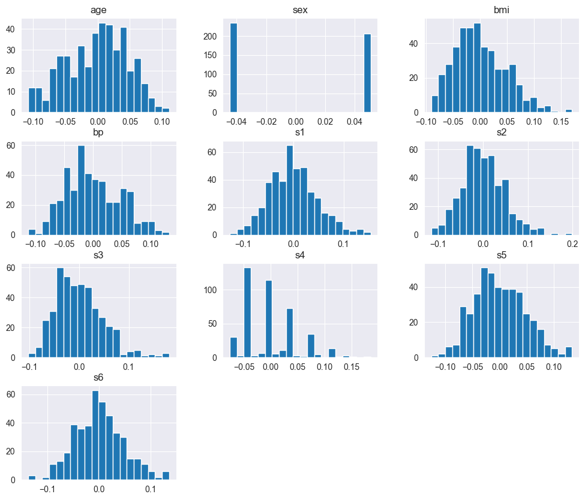

```python
from sklearn import datasets
import pandas as pd
import matplotlib.pyplot as plt

# Load the diabetes dataset
diabetes_data = datasets.load_diabetes()

# Convert it to a DataFrame
diabetes_df = pd.DataFrame(data=diabetes_data.data, columns=diabetes_data.feature_names)

# Create histograms for each column
diabetes_df.hist(bins=20, figsize=(12, 10))
plt.show()
```

```
Available features: ['age', 'sex', 'bmi', 'bp', 's1', 's2', 's3', 's4', 's5', 's6']
```

[figure not shown]

```python
import pandas as pd
import seaborn as sns
import matplotlib.pyplot as plt
from sklearn import datasets

# Load the diabetes dataset
diabetes_data = datasets.load_diabetes()

# Convert to a DataFrame
diabetes_df = pd.DataFrame(data=diabetes_data.data, columns=diabetes_data.feature_names)

# Display the available features
print("Available features:", diabetes_df.columns.tolist())

# Create a mock 'Outcome' column based on 'bmi' for this example
# You can change this logic based on your actual target variable if you have it
diabetes_df['Outcome'] = [1 if x > 30 else 0 for x in diabetes_df['bmi']]

# Create the scatter plot
sns.scatterplot(x='bmi', y='Outcome', data=diabetes_df)
plt.title('Scatter Plot of BMI vs Diabetes Outcome')
plt.xlabel('Body Mass Index (BMI)')
plt.ylabel('Diabetes Outcome (1 = Diabetes, 0 = No Diabetes)')
plt.show()
```

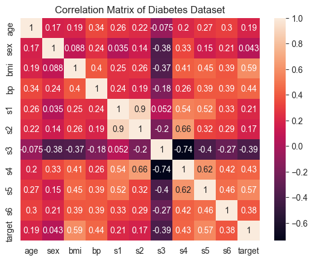

```python
import pandas as pd
import seaborn as sns
import matplotlib.pyplot as plt
from sklearn.datasets import load_diabetes

# Load the diabetes dataset
diabetes_data = load_diabetes()

# Convert to DataFrame
diabetes_df = pd.DataFrame(data=diabetes_data.data, columns=diabetes_data.feature_names)
diabetes_df['target'] = diabetes_data.target  # Add target variable

# Calculate the correlation matrix
correlation_matrix = diabetes_df.corr()

# Create a heatmap
sns.heatmap(correlation_matrix, annot=True)
plt.title("Correlation Matrix of Diabetes Dataset")
plt.show()
```

```python
# Check for missing values
missing_values = diabetes_df.isnull().sum()
print(missing_values)
```

```
age       0
sex       0
bmi       0
bp        0
s1        0
s2        0
s3        0
s4        0
s5        0
s6        0
target    0
dtype: int64
```

### 4. Clean the data if needed, and explain your reasoning for your reader (1 point)

```python
import pandas as pd
from sklearn.datasets import load_diabetes

# Load the diabetes dataset
diabetes_data = load_diabetes()

# Convert to DataFrame
diabetes_df = pd.DataFrame(data=diabetes_data.data, columns=diabetes_data.feature_names)
diabetes_df['target'] = diabetes_data.target  # Add target variable

# Check for duplicate rows
duplicates = diabetes_df.duplicated().sum()
print(f"Number of duplicate rows: {duplicates}")
```

```
Number of duplicate rows: 0
```

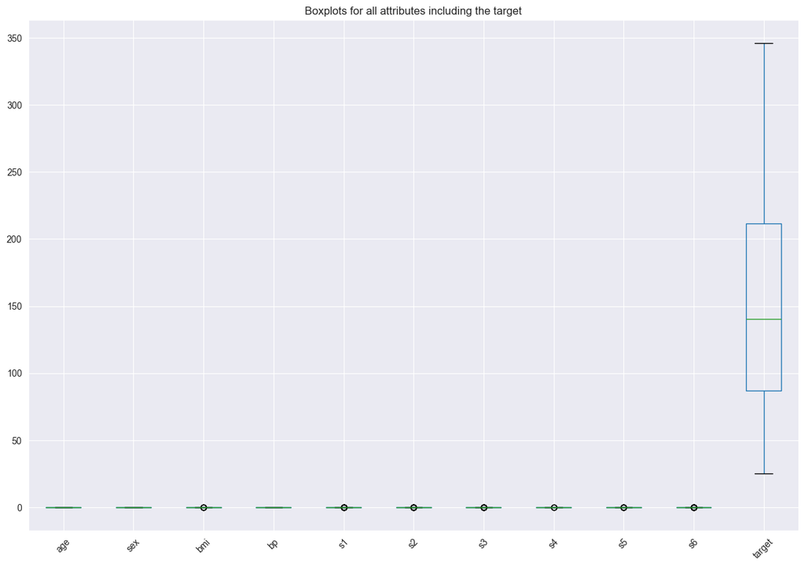

```python
import pandas as pd
from sklearn.datasets import load_diabetes
import matplotlib.pyplot as plt

# Load the diabetes dataset
diabetes_data = load_diabetes()

# Convert to DataFrame
diabetes_df = pd.DataFrame(data=diabetes_data.data, columns=diabetes_data.feature_names)

# Add target variable to DataFrame
diabetes_df['target'] = diabetes_data.target

# Create boxplots for all attributes (including the target variable)
plt.figure(figsize=(15, 10))  # Adjust figure size
diabetes_df.boxplot()  # Boxplot for all columns
plt.xticks(rotation=45)  # Rotate x-axis labels for better readability
plt.title('Boxplots for all attributes including the target')
plt.show()
```

```python
from sklearn.preprocessing import MinMaxScaler

# Check existing columns
print(diabetes_df.columns)

# Define the columns you want to scale
# Change 'glucose' and 'bloodpressure' to the actual column names you want to scale
columns_to_scale = ['bmi', 'bp']  # Update this list as needed

# Initialize the scaler
scaler = MinMaxScaler()

# Fit and transform the selected columns
diabetes_df[columns_to_scale] = scaler.fit_transform(diabetes_df[columns_to_scale])

# Check the scaled DataFrame
print(diabetes_df.head())
```

```
Index(['age', 'sex', 'bmi', 'bp', 's1', 's2', 's3', 's4', 's5', 's6',
       'target'],
      dtype='object')
        age       sex       bmi        bp        s1        s2        s3  \
0  0.038076  0.050680  0.582645  0.549296 -0.044223 -0.034821 -0.043401
1 -0.001882 -0.044642  0.148760  0.352113 -0.008449 -0.019163  0.074412
2  0.085299  0.050680  0.516529  0.436620 -0.045599 -0.034194 -0.032356
3 -0.089063 -0.044642  0.301653  0.309859  0.012191  0.024991 -0.036038
4  0.005383 -0.044642  0.206612  0.549296  0.003935  0.015596  0.008142

         s4        s5        s6  target
0 -0.002592  0.019907 -0.017646   151.0
1 -0.039493 -0.068332 -0.092204    75.0
2 -0.002592  0.002861 -0.025930   141.0
3  0.034309  0.022688 -0.009362   206.0
4 -0.002592 -0.031988 -0.046641   135.0
```

```python
# Convert the Bunch object to a DataFrame
diabetes_df = pd.DataFrame(data=diabetes_data.data, columns=diabetes_data.feature_names)

# Add the target variable as a new column
diabetes_df['target'] = diabetes_data.target

# Display the first few rows of the DataFrame
print(diabetes_df.head())
```

```
        age       sex       bmi        bp        s1        s2        s3  \
0  0.038076  0.050680  0.061696  0.021872 -0.044223 -0.034821 -0.043401
1 -0.001882 -0.044642 -0.051474 -0.026328 -0.008449 -0.019163  0.074412
2  0.085299  0.050680  0.044451 -0.005670 -0.045599 -0.034194 -0.032356
3 -0.089063 -0.044642 -0.011595 -0.036656  0.012191  0.024991 -0.036038
4  0.005383 -0.044642 -0.036385  0.021872  0.003935  0.015596  0.008142

         s4        s5        s6  target
0 -0.002592  0.019907 -0.017646   151.0
1 -0.039493 -0.068332 -0.092204    75.0
2 -0.002592  0.002861 -0.025930   141.0
3  0.034309  0.022688 -0.009362   206.0
4 -0.002592 -0.031988 -0.046641   135.0
```

```python
df = pd.DataFrame(diabetes_data.data, columns=diabetes_data.feature_names)
print(df.columns)
print(df.head())
```

```
Index(['age', 'sex', 'bmi', 'bp', 's1', 's2', 's3', 's4', 's5', 's6'], dtype='object')
        age       sex       bmi        bp        s1        s2        s3  \
0  0.038076  0.050680  0.061696  0.021872 -0.044223 -0.034821 -0.043401
1 -0.001882 -0.044642 -0.051474 -0.026328 -0.008449 -0.019163  0.074412
2  0.085299  0.050680  0.044451 -0.005670 -0.045599 -0.034194 -0.032356
3 -0.089063 -0.044642 -0.011595 -0.036656  0.012191  0.024991 -0.036038
4  0.005383 -0.044642 -0.036385  0.021872  0.003935  0.015596  0.008142

         s4        s5        s6
0 -0.002592  0.019907 -0.017646
1 -0.039493 -0.068332 -0.092204
2 -0.002592  0.002861 -0.025930
3  0.034309  0.022688 -0.009362
4 -0.002592 -0.031988 -0.046641
```

```python
print(diabetes_data.data.shape)
```

```
(442, 10)
```

```python
print(diabetes_df.dtypes)
```

```
age       float64
sex       float64
bmi       float64
bp        float64
s1        float64
s2        float64
s3        float64
s4        float64
s5        float64
s6        float64
target    float64
dtype: object
```

```python
# Assuming diabetes_data is the Bunch object from scikit-learn
diabetes_df = pd.DataFrame(diabetes_data.data, columns=diabetes_data.feature_names)
```

```python
from sklearn.model_selection import train_test_split

diabetes_data_values = diabetes_df.values
train_val_data, test_data = train_test_split(diabetes_data_values, test_size=0.15, random_state=42)
```

# Part 2

### 6. Models: a univariate polynomial regression on the BMI feature versus the "disease progression one year after baseline" - from degree 0 to 5 (6 models) (1.5 point)

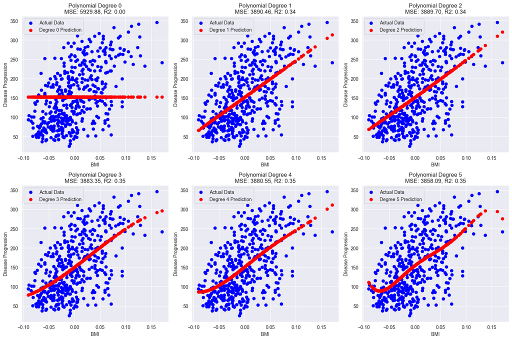

```python
import numpy as np
import pandas as pd
import matplotlib.pyplot as plt
from sklearn.preprocessing import PolynomialFeatures
from sklearn.linear_model import LinearRegression
from sklearn.metrics import mean_squared_error, r2_score
from sklearn.datasets import load_diabetes

# Load the diabetes dataset
diabetes_data = load_diabetes()
X = diabetes_data.data
y = diabetes_data.target

# Convert to a pandas DataFrame for easier manipulation
diabetes_df = pd.DataFrame(X, columns=diabetes_data.feature_names)
# Select the BMI feature and target (disease progression)
X_bmi = diabetes_df[['bmi']]  # BMI feature
y_progression = y  # Disease progression (target)
# Prepare arrays to store results for plotting later
degrees = [0, 1, 2, 3, 4, 5]
mse_values = []
r2_values = []

# Create subplots for visualization
plt.figure(figsize=(15, 10))

for degree in degrees:
    # Create polynomial features for the given degree
    poly_features = PolynomialFeatures(degree=degree)
    X_bmi_poly = poly_features.fit_transform(X_bmi)

    # Train the model
    model = LinearRegression()
    model.fit(X_bmi_poly, y_progression)

    # Predictions
    y_pred = model.predict(X_bmi_poly)

    # Calculate performance metrics
    mse = mean_squared_error(y_progression, y_pred)
    r2 = r2_score(y_progression, y_pred)

    # Store the metrics
    mse_values.append(mse)
    r2_values.append(r2)

    # Plot the results
    plt.subplot(2, 3, degree + 1)  # Create subplots for each model
    plt.scatter(X_bmi, y_progression, color='blue', label="Actual Data")
    plt.scatter(X_bmi, y_pred, color='red', label=f"Degree {degree} Prediction")
    plt.xlabel("BMI")
    plt.ylabel("Disease Progression")
    plt.title(f"Polynomial Degree {degree}\nMSE: {mse:.2f}, R2: {r2:.2f}")
    plt.legend()

# Adjust layout
plt.tight_layout()
plt.show()
```

### 7. Compare the models using the training and validation data. Construct a table summarizing the train validation results. Each model should have a separate row in the table (3 points):

```
1. R-Squared
2. Mean Absolute Error (MAE)
3. MAPE
```

```python
from sklearn.model_selection import train_test_split
from sklearn.metrics import mean_absolute_error, r2_score

# Step 1: Split the data into training and validation sets
X_bmi_train, X_bmi_val, y_train, y_val = train_test_split(X_bmi, y_progression, test_size=0.2, random_state=42)

# Prepare arrays to store results for the summary table
model_results = []

# Step 2: Fit and evaluate polynomial models from degree 0 to 5
for degree in degrees:
    # Create polynomial features
    poly_features = PolynomialFeatures(degree=degree)
    X_bmi_train_poly = poly_features.fit_transform(X_bmi_train)
    X_bmi_val_poly = poly_features.transform(X_bmi_val)

    # Train the model
    model = LinearRegression()
    model.fit(X_bmi_train_poly, y_train)

    # Predictions
    y_train_pred = model.predict(X_bmi_train_poly)
    y_val_pred = model.predict(X_bmi_val_poly)

    # Step 3: Calculate evaluation metrics
    r2_train = r2_score(y_train, y_train_pred)
    r2_val = r2_score(y_val, y_val_pred)

    mae_train = mean_absolute_error(y_train, y_train_pred)
    mae_val = mean_absolute_error(y_val, y_val_pred)

    mape_train = np.mean(np.abs((y_train - y_train_pred) / y_train)) * 100
    mape_val = np.mean(np.abs((y_val - y_val_pred) / y_val)) * 100

    # Append the results to the summary table
    model_results.append({
        'Degree': degree,
        'Train R²': r2_train,
        'Train MAE': mae_train,
        'Train MAPE (%)': mape_train,
        'Validation R²': r2_val,
        'Validation MAE': mae_val,
        'Validation MAPE (%)': mape_val
    })

# Step 4: Create a DataFrame for the results
results_df = pd.DataFrame(model_results)

# Display the summary table
print(results_df)
```

```
   Degree  Train R²  Train MAE  Train MAPE (%)  Validation R²  Validation MAE  \
0       0  0.000000  66.448154       62.930150      -0.011963       64.006461
1       1  0.365724  51.379728       47.570352       0.233350       52.259976
2       2  0.366511  51.326554       47.520822       0.228972       52.383912
3       3  0.366656  51.280115       47.444098       0.232856       52.181400
4       4  0.369518  51.100321       47.131051       0.202336       52.376339
5       5  0.370719  51.008702       47.032820       0.228817       51.884611

   Validation MAPE (%)
0            62.791796
1            45.877478
2            45.996956
3            45.892785
4            45.523299
5            45.194279
```

### 8. Identify the best model based on the table above.

Points to consider for choosing the best model :

1. If the R Squared value is higher it indicates a better fit of the model of the data
2. A lower MAE indicates that the model's predictions are closer to the actual values
3. A lower MAPE indicates better accuracy in percentage terms.

Analysis:

R²: The highest validation R² is 0.233350 for the model of degree 1.

MAE: The lowest validation MAE is 51.884611 for the model of degree 5.

MAPE: The lowest validation MAPE is 45.194279 for the model of degree 5.

Conclusion:

Best Model: Considering all metrics, the model of degree 5 appears to be the best choice. It has the lowest validation MAE and MAPE, indicating that it makes more accurate predictions compared to the other models, despite a lower R² compared to degree 1.

### 9. Run the chosen model on the test set and provide results (R-Squared, MAPE, MAE) (1 point).

```python
import numpy as np
import pandas as pd
from sklearn.preprocessing import PolynomialFeatures
from sklearn.linear_model import LinearRegression
from sklearn.metrics import r2_score, mean_absolute_error, mean_absolute_percentage_error

# Check the type and shape of test_data
print("Type of test_data:", type(test_data))
print("Shape of test_data:", test_data.shape)

# If test_data is a numpy array, convert it back to DataFrame
if isinstance(test_data, np.ndarray):
    num_columns = test_data.shape[1]
    print(f"Number of columns in test_data: {num_columns}")

    # Adjust this to match the actual columns in your test_data
    column_names = ['Column1', 'Column2', 'BMI', 'Column4', 'Column5',
                    'Column6', 'Column7', 'Column8', 'Column9', 'disease_progression']

    # Create DataFrame with the correct number of columns
    test_data = pd.DataFrame(test_data, columns=column_names)

# Step 1: Check the structure of the test_data DataFrame
print("Columns in test_data:", test_data.columns)

# Ensure you pick the correct columns based on your data
X_test = test_data[['BMI']]
y_test = test_data['disease_progression']

# Step 3: Transform the test set features using PolynomialFeatures
poly_features = PolynomialFeatures(degree=5)
X_test_poly = poly_features.fit_transform(X_test)

# Check the train_val_data structure
print("Type of train_val_data:", type(train_val_data))
print("Shape of train_val_data:", train_val_data.shape)

# Convert train_val_data to DataFrame if it is a NumPy array
if isinstance(train_val_data, np.ndarray):
    column_names_train = ['Column1', 'Column2', 'BMI', 'Column4', 'Column5',
                          'Column6', 'Column7', 'Column8', 'Column9', 'disease_progression']

    train_val_data = pd.DataFrame(train_val_data, columns=column_names_train)

# Ensure train_val_data is a DataFrame and contains the required columns
if isinstance(train_val_data, pd.DataFrame):
    if 'BMI' not in train_val_data.columns or 'disease_progression' not in train_val_data.columns:
        raise ValueError("train_val_data must contain 'BMI' and 'disease_progression' columns.")
else:
    raise TypeError("train_val_data should be a pandas DataFrame.")

# Step 4: Fit the model on the training data if not already done
X_train = train_val_data[['BMI']]
y_train = train_val_data['disease_progression']
X_train_poly = poly_features.fit_transform(X_train)

model = LinearRegression()
model.fit(X_train_poly, y_train)

# Step 5: Make predictions on the test set
y_pred = model.predict(X_test_poly)

# Step 6: Calculate evaluation metrics
r_squared = r2_score(y_test, y_pred)
mae = mean_absolute_error(y_test, y_pred)
mape = mean_absolute_percentage_error(y_test, y_pred) * 100  # Convert to percentage

# Step 7: Display results
results = {
    "R-Squared": r_squared,
    "Mean Absolute Error": mae,
    "Mean Absolute Percentage Error (%)": mape
}

print("Test Set Evaluation Metrics:")
for key, value in results.items():
    print(f"{key}: {value:.4f}")
```

```
Type of test_data: <class 'numpy.ndarray'>
Shape of test_data: (67, 10)
Number of columns in test_data: 10
Columns in test_data: Index(['Column1', 'Column2', 'BMI', 'Column4', 'Column5', 'Column6', 'Column7',
       'Column8', 'Column9', 'disease_progression'],
      dtype='object')
Type of train_val_data: <class 'numpy.ndarray'>
Shape of train_val_data: (375, 10)
Test Set Evaluation Metrics:
R-Squared: -0.0597
Mean Absolute Error: 0.0351
Mean Absolute Percentage Error (%): 219.9411
```

### 10. Plot a graph of the train, validation and test data points, and the fit of the chosen model over each of them (1 point).

```python
pip install matplotlib
```

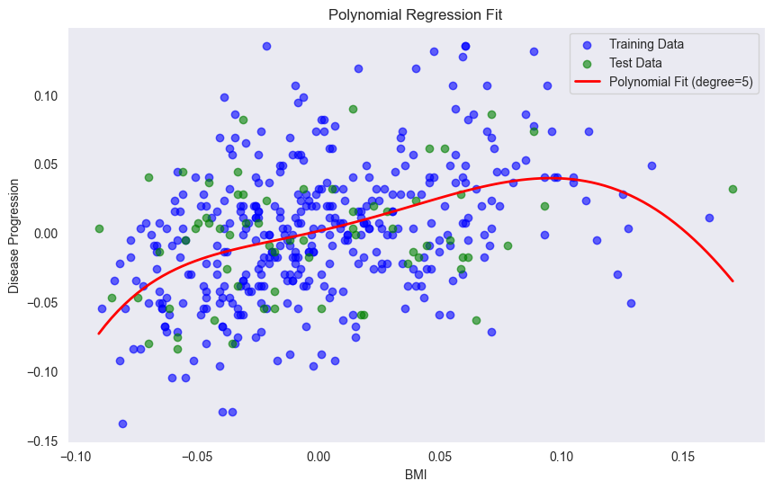

```python
import numpy as np
import pandas as pd
import matplotlib.pyplot as plt
from sklearn.preprocessing import PolynomialFeatures
from sklearn.linear_model import LinearRegression
from sklearn.metrics import r2_score, mean_absolute_error, mean_absolute_percentage_error

# Your existing data preparation code...

# After fitting the model, add the following code for plotting

# Generate a range of values for BMI for plotting the fit
BMI_range = np.linspace(test_data['BMI'].min(), test_data['BMI'].max(), 100).reshape(-1, 1)

# Convert BMI_range to DataFrame to avoid warnings
BMI_range_df = pd.DataFrame(BMI_range, columns=['BMI'])

# Transform the range for polynomial features
BMI_range_poly = poly_features.transform(BMI_range_df)
y_fit = model.predict(BMI_range_poly)

# Plotting
plt.figure(figsize=(10, 6))

# Scatter plot for training data
plt.scatter(X_train, y_train, color='blue', label='Training Data', alpha=0.6)

# Scatter plot for test data
plt.scatter(X_test, y_test, color='green', label='Test Data', alpha=0.6)

# Plot the polynomial fit
plt.plot(BMI_range_df, y_fit, color='red', label='Polynomial Fit (degree=5)', linewidth=2)

# Adding labels and title
plt.title('Polynomial Regression Fit')
plt.xlabel('BMI')
plt.ylabel('Disease Progression')
plt.legend()
plt.grid()
plt.show()
```

### 11. Write down the equation of the best model (with a two decimal digit precision, assuming it's sufficient) (1 point).

```python
# Extracting the coefficients
coefficients = model.coef_
intercept = model.intercept_

# Creating the equation
equation_terms = [f"{intercept:.2f}"]  # Start with the intercept

# Adding polynomial terms
for i, coef in enumerate(coefficients):
    if i > 0:  # Skip the intercept term
        equation_terms.append(f"{coef:.2f}*x^{i}")

# Join terms to create the final equation string
equation = " + ".join(equation_terms)

# Display the equation
print("Equation of the best model:")
print(equation)
```

```
Equation of the best model:
0.00 + 0.40*x^1 + 1.81*x^2 + 17.04*x^3 + -493.06*x^4 + 1214.54*x^5
```

### 12. Calculate the expected diabetes progression for a BMI value of your choice using `model.perdict()` for that value (0.5 point).

```python
# Step 1: Transform the test set features using PolynomialFeatures with a lower degree
poly_features = PolynomialFeatures(degree=2)  # or degree=3
X_train_poly = poly_features.fit_transform(X_train)
X_test_poly = poly_features.transform(X_test)

# Then fit the model and make predictions again
model = LinearRegression()
model.fit(X_train_poly, y_train)
y_pred = model.predict(X_test_poly)
print(f"Expected diabetes progression for a BMI of {chosen_BMI}: {expected_progression[0]:.2f}")
```

[output not shown]

### 13. How many trainable parameters are we fitting for each of the models? Explain these values. One way is to use sklearn function `get_feature_names_out()`(1 point)

```python
# Step 1: Create PolynomialFeatures with the desired degree
poly_features = PolynomialFeatures(degree=5)

# Step 2: Fit the polynomial features on the training data
X_train_poly = poly_features.fit_transform(X_train)

# Step 3: Get the feature names
feature_names = poly_features.get_feature_names_out()

# Step 4: Calculate the number of trainable parameters
n_parameters = len(feature_names)

# Display the feature names and the number of parameters
print("Feature names after polynomial transformation:")
print(feature_names)
print(f"Number of trainable parameters: {n_parameters}")
```

```
Feature names after polynomial transformation:
['1' 'BMI' 'BMI^2' 'BMI^3' 'BMI^4' 'BMI^5']
Number of trainable parameters: 6
```

Explanation for the values:

1. Bias Term ('1'):

The bias term allows the model to make predictions even when all input features are zero, effectively representing the intercept of the regression equation. This constant term is essential for shifting the model's output and improving its fit to the data.

2. Linear Term ('BMI'):

This term indicates the direct effect of BMI on disease progression, capturing the linear relationship between the two variables. A significant coefficient for this term suggests that an increase in BMI leads to a corresponding increase in disease progression.

3. Polynomial Terms ('BMI^2', 'BMI^3', 'BMI^4', 'BMI^5'):

These terms account for non-linear relationships, allowing the model to capture how the impact of BMI on disease progression changes at different levels. Higher-degree polynomial terms enable the model to adapt to more complex patterns, reflecting acceleration or deceleration in disease progression with varying BMI.

4. Interpretability:

The coefficients for these polynomial terms provide insights into the influence of each feature on the predicted disease progression. For example, a positive coefficient for 'BMI^2' indicates that as BMI increases, the effect on disease progression grows stronger.

5. Overall Model Complexity:

Including multiple polynomial terms increases the model's capacity to fit a broader range of patterns within the data. However, this complexity must be managed carefully to avoid overfitting, where the model captures noise instead of genuine trends.

### 14. Provide a conclusion section. In particular, do a deep dive on where the model fails, and add a short section in the conclusions that describes the model limitations. This should be in addition to summarizing it performance. (1 point).

# Part 3

### Step-1 : Sample Data Preparation -

```python
import numpy as np
import pandas as pd

# Load your dataset
data = pd.read_csv(r'C:\Users\Layanika.V.S\Desktop\Fall24\FML24\Lab - 2 - CSCN8010\diabetes_dataset.csv')

# Display the first few rows of the dataset
print(data.head())

# Check for missing values
print(data.isnull().sum())

# Drop columns if necessary based on EDA insights
# data = data.drop(columns=['ColumnToDrop'])

# Separate features (X) and target variable (y)
X = data.drop('disease_progression', axis=1)
y = data['disease_progression']
```

```
        age       sex       bmi        bp        s1        s2        s3  \
0  0.038076  0.050680  0.061696  0.021872 -0.044223 -0.034821 -0.043401
1 -0.001882 -0.044642 -0.051474 -0.026328 -0.008449 -0.019163  0.074412
2  0.085299  0.050680  0.044451 -0.005670 -0.045599 -0.034194 -0.032356
3 -0.089063 -0.044642 -0.011595 -0.036656  0.012191  0.024991 -0.036038
4  0.005383 -0.044642 -0.036385  0.021872  0.003935  0.015596  0.008142

         s4        s5        s6  disease_progression
0 -0.002592  0.019907 -0.017646                151.0
1 -0.039493 -0.068332 -0.092204                 75.0
2 -0.002592  0.002861 -0.025930                141.0
3  0.034309  0.022688 -0.009362                206.0
4 -0.002592 -0.031988 -0.046641                135.0
age                    0
sex                    0
bmi                    0
bp                     0
s1                     0
s2                     0
s3                     0
s4                     0
s5                     0
s6                     0
disease_progression    0
dtype: int64
```

### Step 2 :

#### 1. Two polynomial models (degrees >1, of your choice) -

```python
from sklearn.preprocessing import PolynomialFeatures
from sklearn.linear_model import LinearRegression
from sklearn.model_selection import train_test_split
from sklearn.metrics import r2_score, mean_absolute_error, mean_absolute_percentage_error

# Split data into training and testing sets
X_train, X_test, y_train, y_test = train_test_split(X, y, test_size=0.2, random_state=42)

# Model 1: Polynomial Regression (degree 2)
poly_features_2 = PolynomialFeatures(degree=2)
X_train_poly_2 = poly_features_2.fit_transform(X_train)
X_test_poly_2 = poly_features_2.transform(X_test)

model_poly_2 = LinearRegression()
model_poly_2.fit(X_train_poly_2, y_train)
y_pred_poly_2 = model_poly_2.predict(X_test_poly_2)

# Model 2: Polynomial Regression (degree 3)
poly_features_3 = PolynomialFeatures(degree=3)
X_train_poly_3 = poly_features_3.fit_transform(X_train)
X_test_poly_3 = poly_features_3.transform(X_test)

model_poly_3 = LinearRegression()
model_poly_3.fit(X_train_poly_3, y_train)
y_pred_poly_3 = model_poly_3.predict(X_test_poly_3)

# Evaluate both models
metrics_poly_2 = {
    "R-Squared": r2_score(y_test, y_pred_poly_2),
    "MAE": mean_absolute_error(y_test, y_pred_poly_2),
    "MAPE (%)": mean_absolute_percentage_error(y_test, y_pred_poly_2) * 100
}

metrics_poly_3 = {
    "R-Squared": r2_score(y_test, y_pred_poly_3),
    "MAE": mean_absolute_error(y_test, y_pred_poly_3),
    "MAPE (%)": mean_absolute_percentage_error(y_test, y_pred_poly_3) * 100
}

print("Polynomial Regression (Degree 2) Metrics:", metrics_poly_2)
print("Polynomial Regression (Degree 3) Metrics:", metrics_poly_3)
```

```
Polynomial Regression (Degree 2) Metrics: {'R-Squared': 0.41563993364077667, 'MAE': 43.58169325465436, 'MAPE (%)': 38.2856785140032}
Polynomial Regression (Degree 3) Metrics: {'R-Squared': -15.355434337638496, 'MAE': 174.04494382022472, 'MAPE (%)': 156.32157412863657}
```

#### 2. Two decision trees (e.g. consider changing the `max_depth` hyperparameter) -

```python
from sklearn.tree import DecisionTreeRegressor

# Model 1: Decision Tree with max_depth=3
model_dt_3 = DecisionTreeRegressor(max_depth=3, random_state=42)
model_dt_3.fit(X_train, y_train)
y_pred_dt_3 = model_dt_3.predict(X_test)

# Model 2: Decision Tree with max_depth=5
model_dt_5 = DecisionTreeRegressor(max_depth=5, random_state=42)
model_dt_5.fit(X_train, y_train)
y_pred_dt_5 = model_dt_5.predict(X_test)

# Evaluate both models
metrics_dt_3 = {
    "R-Squared": r2_score(y_test, y_pred_dt_3),
    "MAE": mean_absolute_error(y_test, y_pred_dt_3),
    "MAPE (%)": mean_absolute_percentage_error(y_test, y_pred_dt_3) * 100
}

metrics_dt_5 = {
    "R-Squared": r2_score(y_test, y_pred_dt_5),
    "MAE": mean_absolute_error(y_test, y_pred_dt_5),
    "MAPE (%)": mean_absolute_percentage_error(y_test, y_pred_dt_5) * 100
}

print("Decision Tree (max_depth=3) Metrics:", metrics_dt_3)
print("Decision Tree (max_depth=5) Metrics:", metrics_dt_5)
```

[output not shown]

#### 3. Two kNNs -

```python
from sklearn.neighbors import KNeighborsRegressor

# Model 1: kNN with k=3
model_knn_3 = KNeighborsRegressor(n_neighbors=3)
model_knn_3.fit(X_train, y_train)
y_pred_knn_3 = model_knn_3.predict(X_test)

# Model 2: kNN with k=5
model_knn_5 = KNeighborsRegressor(n_neighbors=5)
model_knn_5.fit(X_train, y_train)
y_pred_knn_5 = model_knn_5.predict(X_test)

# Evaluate both models
metrics_knn_3 = {
    "R-Squared": r2_score(y_test, y_pred_knn_3),
    "MAE": mean_absolute_error(y_test, y_pred_knn_3),
    "MAPE (%)": mean_absolute_percentage_error(y_test, y_pred_knn_3) * 100
}

metrics_knn_5 = {
    "R-Squared": r2_score(y_test, y_pred_knn_5),
    "MAE": mean_absolute_error(y_test, y_pred_knn_5),
    "MAPE (%)": mean_absolute_percentage_error(y_test, y_pred_knn_5) * 100
}

print("kNN (k=3) Metrics:", metrics_knn_3)
print("kNN (k=5) Metrics:", metrics_knn_5)
```

[output not shown]